# IODS course project

# Analysis of longitudinal data

Dependencies:

```r
library(dplyr)
library(tidyr)
library(GGally)
library(ggplot2)
library(lme4)
```

Load BPRS data

```r
BPRS <- read.csv("https://raw.githubusercontent.com/KimmoVehkalahti/MABS/master/Examples/data/BPRS.txt", sep  =" ", header = T)
```

Factor treatment and subject:

```r
BPRS$treatment <- factor(BPRS$treatment)
BPRS$subject <- factor(BPRS$subject)
```

Convert to long form and extract the week number:

```r
BPRSL <- BPRS %>% gather(key = weeks, value = bprs, -treatment, -subject)
BPRSL <- BPRSL %>% mutate(week = as.integer(substr(weeks,5,5)))
```

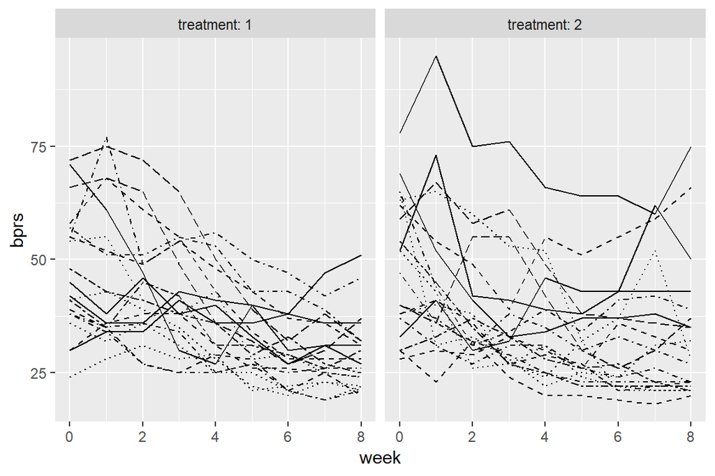

```r
ggplot(BPRSL, aes(x = week, y = bprs, linetype = subject)) +
  geom_line() +
  scale_linetype_manual(values = rep(1:10, times=4)) +
  facet_grid(. ~ treatment, labeller = label_both) +
  theme(legend.position = "none") +
  scale_y_continuous(limits = c(min(BPRSL$bprs), max(BPRSL$bprs)))
```

Standardize bprs:

```r
BPRSL <- BPRSL %>%
  group_by(week) %>%
  mutate(stdbprs = (bprs - mean(bprs))/sd(bprs) ) %>%
  ungroup()
```

Glimpse of the data:

```r
glimpse(BPRSL)
```

```
## Observations: 360
## Variables: 6
## $ treatment <fct> 1, 1, 1, 1, 1, 1, 1, 1, 1, 1, 1, 1, 1, 1, 1, 1, 1, 1...
## $ subject   <fct> 1, 2, 3, 4, 5, 6, 7, 8, 9, 10, 11, 12, 13, 14, 15, 1...
## $ weeks     <chr> "week0", "week0", "week0", "week0", "week0", "week0"...
## $ bprs      <int> 42, 58, 54, 55, 72, 48, 71, 30, 41, 57, 30, 55, 36, ...
## $ week      <int> 0, 0, 0, 0, 0, 0, 0, 0, 0, 0, 0, 0, 0, 0, 0, 0, 0, 0...
## $ stdbprs   <dbl> -0.4245908, 0.7076513, 0.4245908, 0.4953559, 1.69836...
```

Plot with the standardised bprs:

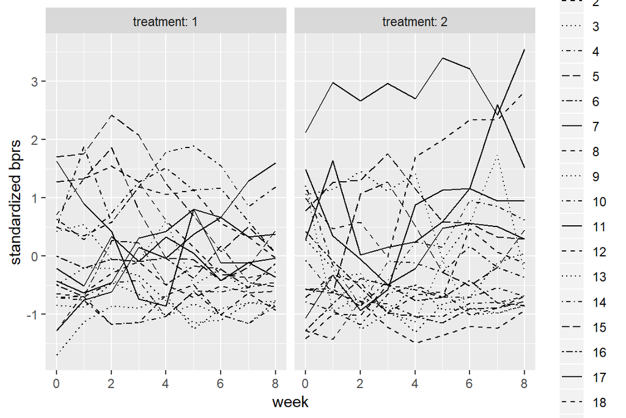

```r
ggplot(BPRSL, aes(x = week, y = stdbprs, linetype = subject)) +
  geom_line() +
  scale_linetype_manual(values = rep(1:10, times=4)) +
  facet_grid(. ~ treatment, labeller = label_both) +
  scale_y_continuous(name = "standardized bprs")
```

Number of weeks, baseline (week 0) included

```r
n <- BPRSL$week %>% unique() %>% length()
```

Summary of the data with mean and standard error of bprs by treatment and week:

```r
BPRSS <- BPRSL %>%
  group_by(treatment, week) %>%
  summarise( mean = mean(bprs), se = sd(bprs)/sqrt(n) ) %>%
  ungroup()
```

Glimpse of the data

```r
glimpse(BPRSS)
```

```
## Observations: 18
## Variables: 4
## $ treatment <fct> 1, 1, 1, 1, 1, 1, 1, 1, 1, 2, 2, 2, 2, 2, 2, 2, 2, 2
## $ week      <int> 0, 1, 2, 3, 4, 5, 6, 7, 8, 0, 1, 2, 3, 4, 5, 6, 7, 8
## $ mean      <dbl> 47.00, 46.80, 43.55, 40.90, 36.60, 32.70, 29.70, 29....
## $ se        <dbl> 4.534468, 5.173708, 4.003617, 3.744626, 3.259534, 2....
```

Mean profiles plot:

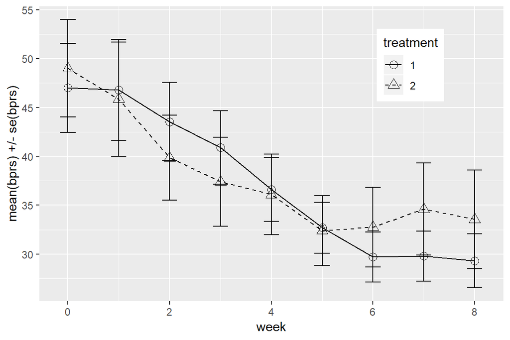

```r
ggplot(BPRSS, aes(x = week, y = mean, linetype = treatment, shape = treatment)) +
  geom_line() +
  scale_linetype_manual(values = c(1,2)) +
  geom_point(size=3) +
  scale_shape_manual(values = c(1,2)) +
  geom_errorbar(aes(ymin = mean - se, ymax = mean + se, linetype="1"), width=0.3) +
  theme(legend.position = c(0.8,0.8)) +
  scale_y_continuous(name = "mean(bprs) +/- se(bprs)")
```

Create a summary data by treatment and subject with mean as the summary variable.

```r
BPRSL8S <- BPRSL %>%
  filter(week > 0) %>%
  group_by(treatment, subject) %>%
  summarise( mean=mean(bprs) ) %>%
  ungroup()
```

Glimpse the data

```r
glimpse(BPRSL8S)
```

```
## Observations: 40
## Variables: 3
## $ treatment <fct> 1, 1, 1, 1, 1, 1, 1, 1, 1, 1, 1, 1, 1, 1, 1, 1, 1, 1...
## $ subject   <fct> 1, 2, 3, 4, 5, 6, 7, 8, 9, 10, 11, 12, 13, 14, 15, 1...
## $ mean      <dbl> 41.500, 43.125, 35.375, 52.625, 50.375, 34.000, 37.1...
```

Draw a boxplot of the mean versus treatment

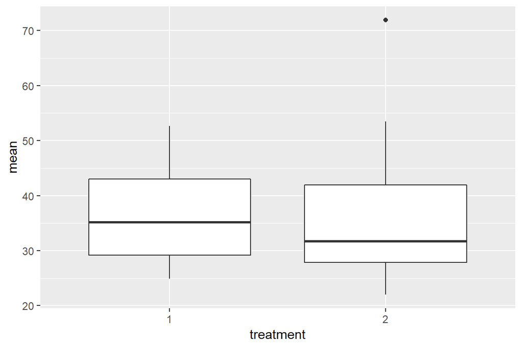

```r
ggplot(BPRSL8S, aes(x = treatment, y = mean)) + geom_boxplot()
```

Add the baseline from the original data as a new variable to the summary data

```r
BPRSL8S2 <- BPRSL8S %>%
  mutate(baseline = BPRS$week0)
```

Perform a two-sample t-test

```r
t.test(mean ~ treatment, data = BPRSL8S2, var.equal = TRUE)
```

```
##
##  Two Sample t-test
##
## data:  mean by treatment
## t = -0.11896, df = 38, p-value = 0.9059
## alternative hypothesis: true difference in means is not equal to 0
## 95 percent confidence interval:
##  -7.094183  6.306683
## sample estimates:
## mean in group 1 mean in group 2
##        36.16875        36.56250
```

Fit the linear model with the mean as the response

```r
fit <- lm(mean ~ baseline + treatment, data = BPRSL8S2)
```

Compute the analysis of variance table for the fitted model

```r
anova(fit)
```

```
## Analysis of Variance Table
##
## Response: mean
##           Df  Sum Sq Mean Sq F value    Pr(>F)
## baseline   1 1868.07 1868.07 30.1437 3.077e-06 ***
## treatment  1    3.45    3.45  0.0557    0.8148
## Residuals 37 2292.97   61.97
## ---
## Signif. codes:  0 '***' 0.001 '**' 0.01 '*' 0.05 '.' 0.1 ' ' 1
```

Load RATSL data

```r
RATS <- read.table("https://raw.githubusercontent.com/KimmoVehkalahti/MABS/master/Examples/data/rats.txt", header = TRUE, sep = '\t')
```

Convert data to long form:

```r
RATSL <- RATS %>%
  gather(key = WD, value = Weight, -ID, -Group) %>%
  mutate(Time = as.integer(substr(WD,3,4)))
```

Regression model of RATSL data:

```r
RATS_reg <- lm(Weight ~ Time + Group, data = RATSL)
```

Summary:

```r
summary(RATS_reg)
```

```
##
## Call:
## lm(formula = Weight ~ Time + Group, data = RATSL)
##
## Residuals:
##     Min      1Q  Median      3Q     Max
## -78.543 -20.884 -14.208   9.803 190.876
##
## Coefficients:
##             Estimate Std. Error t value Pr(>|t|)
## (Intercept) 121.2063    11.3052  10.721   <2e-16 ***
## Time          0.5857     0.2002   2.926   0.0039 **
## Group       139.2169     4.6965  29.643   <2e-16 ***
## ---
## Signif. codes:  0 '***' 0.001 '**' 0.01 '*' 0.05 '.' 0.1 ' ' 1
##
## Residual standard error: 51.66 on 173 degrees of freedom
## Multiple R-squared:  0.8368, Adjusted R-squared:  0.8349
## F-statistic: 443.6 on 2 and 173 DF,  p-value: < 2.2e-16
```

Random intercept model:

```r
RATS_ref <- lmer(Weight ~ Time + Group + (1 | ID), data = RATSL, REML = FALSE)
```

Summary of the model:

```r
summary(RATS_ref)
```

```
## Linear mixed model fit by maximum likelihood  ['lmerMod']
## Formula: Weight ~ Time + Group + (1 | ID)
##    Data: RATSL
##
##      AIC      BIC   logLik deviance df.resid
##   1344.8   1360.7   -667.4   1334.8      171
##
## Scaled residuals:
##     Min      1Q  Median      3Q     Max
## -3.5073 -0.5519 -0.0399  0.5580  3.1303
##
## Random effects:
##  Groups   Name        Variance Std.Dev.
##  ID       (Intercept) 2556.98  50.567
##  Residual               66.44   8.151
## Number of obs: 176, groups:  ID, 16
##
## Fixed effects:
##              Estimate Std. Error t value
## (Intercept) 121.20629   29.57835   4.098
## Time          0.58568    0.03158  18.544
## Group       139.21694   15.26439   9.120
##
## Correlation of Fixed Effects:
##       (Intr) Time
## Time  -0.036
## Group -0.903  0.000
```

Random intercept model and random slope model:

```r
RATS_ref1 <- lmer(Weight ~ Time + Group + (Time | ID), data = RATSL, REML = FALSE)
```

Anova test on the models:

```r
anova(RATS_ref1, RATS_ref)
```

```
## Data: RATSL
## Models:
## RATS_ref: Weight ~ Time + Group + (1 | ID)
## RATS_ref1: Weight ~ Time + Group + (Time | ID)
##           Df    AIC    BIC  logLik deviance  Chisq Chi Df Pr(>Chisq)
## RATS_ref   5 1344.8 1360.7 -667.41   1334.8
## RATS_ref1  7 1200.8 1223.0 -593.41   1186.8 147.99      2  < 2.2e-16 ***
## ---
## Signif. codes:  0 '***' 0.001 '**' 0.01 '*' 0.05 '.' 0.1 ' ' 1
```